# Tarea 4 2023

Arqueología Cuantitativa

Esteban Arroyo

## Cargamos la base de datos

```r
library(readxl)

data_set1 <- read_excel("Base_de_datos_trabajo_4_2023.xlsx", sheet="Niveles")
data_set2 <- read_excel("Base_de_datos_trabajo_4_2023.xlsx", sheet="Sitios")
```

## Cargamos las librerías que vamos a usar

```r
library(nortest)
library(lmtest)
library(fBasics)
library(ggplot2)
library(flextable)
library(dplyr)
```

# Hacemos un preview de nuestros datos

```r
head(data_set1) %>% flextable() %>% set_caption("Base Niveles") %>%
  bg(bg="#0E6655", part = "header") %>% bold(part = "header") %>%
  color(color = "white", part = "header") %>% autofit()
```

Base Niveles

| Nivel | Densidad líticos |
| --- | --- |
| 1 | 908 |
| 2 | 890 |
| 3 | 782 |
| 4 | 670 |
| 5 | 587 |
| 6 | 546 |

```r
head(data_set2) %>% flextable() %>% set_caption("Base Sitios") %>%
  bg(bg="#0E6655", part = "header") %>% bold(part = "header") %>%
  color(color = "white", part = "header") %>% autofit()
```

Base Sitios

| Dist(km) | %Obs |
| --- | --- |
| 15 | 90 |
| 25 | 88 |
| 12 | 80 |
| 60 | 60 |
| 7 | 91 |
| 56 | 92 |

## **Ejercicio 1**

### En la hoja “Niveles” se encuentra la información de densidad de restos líticos en los niveles de un mismo sitio arqueológico (niveles artificiales cada 5 cms). Queremos saber si existe una correlación entre la profundidad y la densidad de restos. Para la anterior desarrolle la prueba de correlación que sea más apropiada, definiendo su intensidad y significancia. No olvide comprobar los supuestos que correspondan. ¿Existe una correlación entre profundidad y densidad de restos líticos? ¿qué dirección adquiere esta relación?

### Solo se evalua normalidad en variable Densidad líticos, ya que Nivel es una variable categórica

### Como las muestras son menores a 50 usaremos Shapiro-Wilk

```r
shapiro.test(data_set1$`Densidad líticos`)
```

```
    Shapiro-Wilk normality test

data:  data_set1$`Densidad líticos`
W = 0.91998, p-value = 0.05834
```

### Aunque la variable Densidad líticos se ajusta a la normal (por muy poco), se realiza la correlación de Spearman porque la variable Nivel es una variable categórica

```r
cor1 <-cor.test(data_set1$`Densidad líticos`, data_set1$Nivel, method="spearman", exact=FALSE)

cor1 %>% as_flextable() %>%
  set_caption("Correlación de Spearman entre NIvel y Densidad líticos") %>%
  bg(bg="#2874A6", part = "header") %>% bold(part = "header") %>%
  color(color = "white", part = "header") %>%
  colformat_double(j= ~ estimate, digits = 4) %>% set_header_labels(estimate = "Estimate", statistic = "Statistic", p.value = "P-value", method = "Method", alternative = "Alternative")%>%
  add_footer_lines("Fuente: Esteban Arroyo") %>% autofit()
```

Correlación de Spearman entre NIvel y Densidad líticos

| Estimate | Statistic | P-value | Method | Alternative |
| --- | --- | --- | --- | --- |
| -0.8563 | 4,269.4 | 0.0000*** | Spearman's rank correlation rho | two.sided |

Signif. codes: 0 <= '***' < 0.001 < '**' < 0.01 < '*' < 0.05  
Fuente: Esteban Arroyo

### Hacemos tambien el gráfico de dispersión

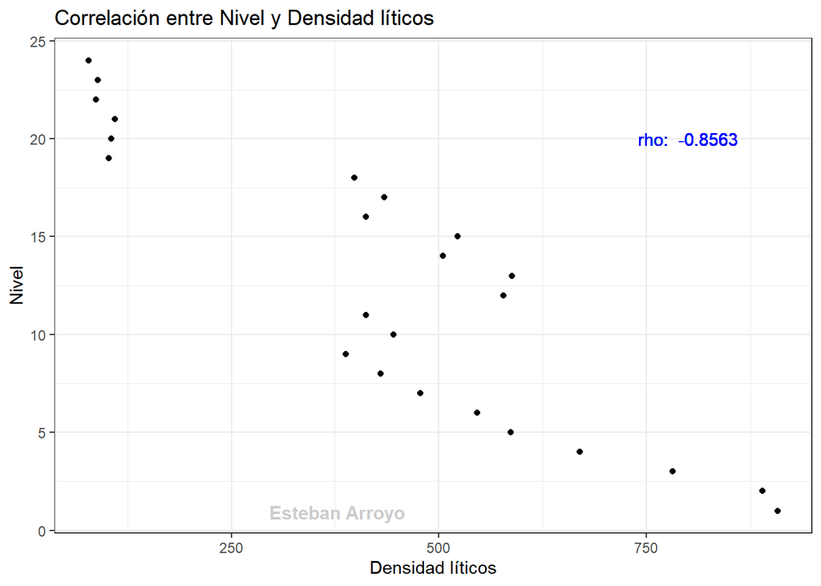

```r
ggplot(data_set1, aes(x = `Densidad líticos`, y = Nivel)) + geom_point() +
  theme_bw() + ggtitle("Correlación entre Nivel y Densidad líticos") +
  annotate("text",x=Inf,y=-Inf,label="Esteban Arroyo",hjust=4,vjust=-1,col="grey",cex=4,fontface = "bold", alpha = 0.8) +
  geom_text(x = 800, y = 20, label = paste("rho: ", round(cor1$estimate, 4)), col="blue"  )
```

### Existe una alta correlación de -0.85 entre Densidad y Nivel, pero al ser negativa es inversa, esto quiere decir que, a medida que la densidad, el nivel de profundidad es menor. Dicho de otra manera, en los nivels superiores existe mayor densidad de material, y a medida que aunta la profundidad, la densidad disminuye.

## **Ejercicio 2**

## En la hoja “Sitios” se encuentra la información de 30 sitios arqueológicos que se encuentran en las inmediaciones de una cantera de obsidiana. Para cada uno de estos sitios, se ha registrado su distancia lineal a la fuente y la proporción de obsidiana dentro de sus conjuntos líticos. Nos interesa saber si el porcentaje de obsidiana de los sitios puede ser predicho a partir de la distancia a la fuente. Para lo anterior, efectúe lo siguiente:

## a) Desarrolle un modelo de regresión lineal

### En este caso como todas variables son contínuas numéricas, comprobamos la normalidad de los datos

```r
shapiro.test(data_set2$`Dist(km)`)    #variable Dist(km)
```

```
    Shapiro-Wilk normality test

data:  data_set2$`Dist(km)`
W = 0.97074, p-value = 0.5596
```

```r
shapiro.test(data_set2$`%Obs`)        #variable %Obs
```

```
    Shapiro-Wilk normality test

data:  data_set2$`%Obs`
W = 0.9606, p-value = 0.3209
```

### Como todas las variables se ajustan a la normal procedemos a realizar una correlación de Pearson

```r
cor2 <-cor.test(data_set2$`Dist(km)`, data_set2$`%Obs`, method="pearson")

cor2 %>% as_flextable() %>%
  set_caption("Correlación de Pearson entre Dist(km) y %Obs") %>%
  bg(bg="#2874A6", part = "header") %>% bold(part = "header") %>%
  color(color = "white", part = "header") %>%
  colformat_double(j= ~ estimate, digits = 4) %>% set_header_labels(estimate = "Estimate", statistic = "Statistic", p.value = "P-value", method = "Method", alternative = "Alternative")%>%
  add_footer_lines("Fuente: Esteban Arroyo") %>% autofit()
```

Correlación de Pearson entre Dist(km) y %Obs

| Estimate | Statistic | P-value | parameter | conf.low | conf.high | Method | Alternative |
| --- | --- | --- | --- | --- | --- | --- | --- |
| -0.8712 | -9.4 | 0.0000*** | 28 | -0.9 | -0.7 | Pearson's product-moment correlation | two.sided |

Signif. codes: 0 <= '***' < 0.001 < '**' < 0.01 < '*' < 0.05  
Fuente: Esteban Arroyo

### Hacemos la regresión

```r
reglineal <- lm(`%Obs`~`Dist(km)`, data=data_set2)

reglineal %>% as_flextable() %>%
  set_caption("Regresión Lineal de la Proporción de Obsidiana en base a la Distancia") %>%
  bg(bg="#154360", part = "header") %>% bold(part = "header") %>%
  color(color = "white", part = "header") %>%
  add_footer_lines("Fuente: Esteban Arroyo") %>% autofit()
```

Regresión Lineal de la Proporción de Obsidiana en base a la Distancia

|  | Estimate | Standard Error | t value | Pr(>\|t\|) |  |
| --- | --- | --- | --- | --- | --- |
| (Intercept) | 89.557 | 5.038 | 17.777 | 0.0000 | *** |
| `Dist(km)` | -0.456 | 0.049 | -9.390 | 0.0000 | *** |

Signif. codes: 0 <= '***' < 0.001 < '**' < 0.01 < '*' < 0.05  
Residual standard error: 13.11 on 28 degrees of freedom  
Multiple R-squared: 0.759, Adjusted R-squared: 0.7504  
F-statistic: 88.17 on 28 and 1 DF, p-value: 0.0000  
Fuente: Esteban Arroyo

## b) Construya la gráfica que corresponde

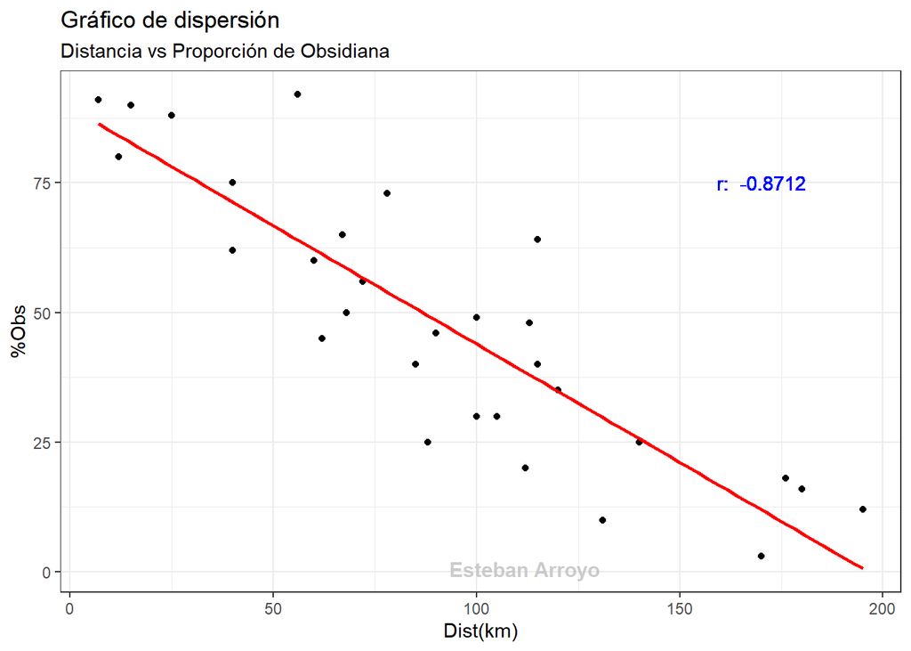

```r
ggplot(data_set2, aes(x = `Dist(km)`, y = `%Obs`)) +
  geom_point() + stat_smooth(method = "lm", formula = y ~ x, col = "red", se = FALSE) +
  theme_bw() + annotate("text",x=Inf,y=-Inf,label="Esteban Arroyo",hjust=3,vjust=-1,col="grey",cex=4,fontface = "bold", alpha = 0.8) +
  geom_text(x = 170, y = 75, label = paste("r: ", round(cor2$estimate, 4)), col="blue"  ) + ggtitle("Gráfico de dispersión", subtitle = "Distancia vs Proporción de Obsidiana")
```

## Comprobamos los supuestos de la regresión

```r
jarqueberaTest(reglineal$residuals)   #Jarque Bera Test
```

```
Title:
 Jarque - Bera Normalality Test

Test Results:
  STATISTIC:
    X-squared: 0.3298
  P VALUE:
    Asymptotic p Value: 0.848

Description:
 Wed Nov 15 13:12:58 2023 by user: eluis
```

```r
bptest(reglineal)                     #Breusch-Pagan test
```

```
    studentized Breusch-Pagan test

data:  reglineal
BP = 0.066401, df = 1, p-value = 0.7967
```

```r
dwtest(reglineal)                     #Durbin-Watson test
```

```
    Durbin-Watson test

data:  reglineal
DW = 1.6955, p-value = 0.1528
alternative hypothesis: true autocorrelation is greater than 0
```

### Podemos observar que el modelo se ajustan a los supuestos

## c) Refiérase al potencial del modelo para predecir el porcentaje de obsidiana en nuevos sitios del área

### El r:-0.8712, Adjusted R-squared: 0.7504 –> Proporción de Obsidiana en base a la Distancia. Esto quiere decir que la Proporción de Obsidiana es explicada por la Distancia en un 75% aproximadamente. Es decir, la proporción o cantidad de Obsidiana estimada depende de un 75% de la distancia del sitio a la cantera.

### Por lo tanto, coeficientes a usar en el modelo de regresión son:

## **Proporción de Obsidiana = 89.5568 + Distancia(km)*-0.45623**